# Risk Factor Analysis

## Outcome Variable

**Outcome Variable:** sstunted

## Predictor Variables

**Intervention Variable:** birthwt

**Adjustment Set:**

unadjusted

## Stratifying Variables

The analysis was stratified on these variable(s):

- agecat
- studyid
- country

## Data Summary

| agecat | studyid | country | A | n | nA | nAY0 | nAY1 |
| --- | --- | --- | --- | --- | --- | --- | --- |
| Birth | ki0047075b-MAL-ED | BANGLADESH | >=0 | 257 | 34 | 34 | 0 |
| Birth | ki0047075b-MAL-ED | BANGLADESH | <-3 | 257 | 7 | 2 | 5 |
| Birth | ki0047075b-MAL-ED | BANGLADESH | [-3–2) | 257 | 38 | 35 | 3 |
| Birth | ki0047075b-MAL-ED | BANGLADESH | [-2–1) | 257 | 96 | 95 | 1 |
| Birth | ki0047075b-MAL-ED | BANGLADESH | [-1-0) | 257 | 82 | 82 | 0 |
| Birth | ki0047075b-MAL-ED | BRAZIL | >=0 | 191 | 111 | 110 | 1 |
| Birth | ki0047075b-MAL-ED | BRAZIL | <-3 | 191 | 0 | 0 | 0 |
| Birth | ki0047075b-MAL-ED | BRAZIL | [-3–2) | 191 | 6 | 3 | 3 |
| Birth | ki0047075b-MAL-ED | BRAZIL | [-2–1) | 191 | 19 | 16 | 3 |
| Birth | ki0047075b-MAL-ED | BRAZIL | [-1-0) | 191 | 55 | 54 | 1 |
| Birth | ki0047075b-MAL-ED | INDIA | >=0 | 206 | 40 | 40 | 0 |
| Birth | ki0047075b-MAL-ED | INDIA | <-3 | 206 | 2 | 0 | 2 |
| Birth | ki0047075b-MAL-ED | INDIA | [-3–2) | 206 | 21 | 20 | 1 |
| Birth | ki0047075b-MAL-ED | INDIA | [-2–1) | 206 | 68 | 65 | 3 |
| Birth | ki0047075b-MAL-ED | INDIA | [-1-0) | 206 | 75 | 74 | 1 |
| Birth | ki0047075b-MAL-ED | NEPAL | >=0 | 173 | 32 | 32 | 0 |
| Birth | ki0047075b-MAL-ED | NEPAL | <-3 | 173 | 4 | 1 | 3 |
| Birth | ki0047075b-MAL-ED | NEPAL | [-3–2) | 173 | 12 | 10 | 2 |
| Birth | ki0047075b-MAL-ED | NEPAL | [-2–1) | 173 | 40 | 39 | 1 |
| Birth | ki0047075b-MAL-ED | NEPAL | [-1-0) | 173 | 85 | 85 | 0 |
| Birth | ki0047075b-MAL-ED | PERU | >=0 | 287 | 90 | 90 | 0 |
| Birth | ki0047075b-MAL-ED | PERU | <-3 | 287 | 4 | 1 | 3 |
| Birth | ki0047075b-MAL-ED | PERU | [-3–2) | 287 | 9 | 7 | 2 |
| Birth | ki0047075b-MAL-ED | PERU | [-2–1) | 287 | 42 | 39 | 3 |
| Birth | ki0047075b-MAL-ED | PERU | [-1-0) | 287 | 142 | 142 | 0 |
| Birth | ki0047075b-MAL-ED | SOUTH AFRICA | >=0 | 262 | 91 | 91 | 0 |
| Birth | ki0047075b-MAL-ED | SOUTH AFRICA | <-3 | 262 | 5 | 4 | 1 |
| Birth | ki0047075b-MAL-ED | SOUTH AFRICA | [-3–2) | 262 | 11 | 10 | 1 |
| Birth | ki0047075b-MAL-ED | SOUTH AFRICA | [-2–1) | 262 | 39 | 39 | 0 |
| Birth | ki0047075b-MAL-ED | SOUTH AFRICA | [-1-0) | 262 | 116 | 116 | 0 |

[output cut: 875 more lines]

The following strata were considered:

- agecat: 12 months, studyid: ki0047075b-MAL-ED, country: BANGLADESH
- agecat: 12 months, studyid: ki0047075b-MAL-ED, country: BRAZIL
- agecat: 12 months, studyid: ki0047075b-MAL-ED, country: INDIA
- agecat: 12 months, studyid: ki0047075b-MAL-ED, country: NEPAL
- agecat: 12 months, studyid: ki0047075b-MAL-ED, country: PERU
- agecat: 12 months, studyid: ki0047075b-MAL-ED, country: SOUTH AFRICA
- agecat: 12 months, studyid: ki0047075b-MAL-ED, country: TANZANIA, UNITED REPUBLIC OF
- agecat: 12 months, studyid: ki1000108-CMC-V-BCS-2002, country: INDIA
- agecat: 12 months, studyid: ki1000108-IRC, country: INDIA
- agecat: 12 months, studyid: ki1000109-EE, country: PAKISTAN
- agecat: 12 months, studyid: ki1000109-ResPak, country: PAKISTAN
- agecat: 12 months, studyid: ki1000304b-SAS-CompFeed, country: INDIA
- agecat: 12 months, studyid: ki1017093-NIH-Birth, country: BANGLADESH
- agecat: 12 months, studyid: ki1017093b-PROVIDE, country: BANGLADESH
- agecat: 12 months, studyid: ki1017093c-NIH-Crypto, country: BANGLADESH
- agecat: 12 months, studyid: ki1066203-TanzaniaChild2, country: TANZANIA, UNITED REPUBLIC OF
- agecat: 12 months, studyid: ki1101329-Keneba, country: GAMBIA
- agecat: 12 months, studyid: ki1114097-CMIN, country: BRAZIL
- agecat: 12 months, studyid: ki1114097-CMIN, country: PERU
- agecat: 12 months, studyid: ki1114097-CONTENT, country: PERU
- agecat: 12 months, studyid: ki1119695-PROBIT, country: BELARUS
- agecat: 12 months, studyid: ki1126311-ZVITAMBO, country: ZIMBABWE
- agecat: 12 months, studyid: ki1135781-COHORTS, country: GUATEMALA
- agecat: 12 months, studyid: ki1135781-COHORTS, country: INDIA
- agecat: 12 months, studyid: ki1135781-COHORTS, country: PHILIPPINES
- agecat: 12 months, studyid: kiGH5241-JiVitA-3, country: BANGLADESH
- agecat: 12 months, studyid: kiGH5241-JiVitA-4, country: BANGLADESH
- agecat: 18 months, studyid: ki0047075b-MAL-ED, country: BANGLADESH
- agecat: 18 months, studyid: ki0047075b-MAL-ED, country: BRAZIL
- agecat: 18 months, studyid: ki0047075b-MAL-ED, country: INDIA
- agecat: 18 months, studyid: ki0047075b-MAL-ED, country: NEPAL
- agecat: 18 months, studyid: ki0047075b-MAL-ED, country: PERU
- agecat: 18 months, studyid: ki0047075b-MAL-ED, country: SOUTH AFRICA
- agecat: 18 months, studyid: ki0047075b-MAL-ED, country: TANZANIA, UNITED REPUBLIC OF
- agecat: 18 months, studyid: ki1000108-CMC-V-BCS-2002, country: INDIA
- agecat: 18 months, studyid: ki1000108-IRC, country: INDIA
- agecat: 18 months, studyid: ki1000109-EE, country: PAKISTAN
- agecat: 18 months, studyid: ki1000109-ResPak, country: PAKISTAN
- agecat: 18 months, studyid: ki1000304b-SAS-CompFeed, country: INDIA
- agecat: 18 months, studyid: ki1017093-NIH-Birth, country: BANGLADESH
- agecat: 18 months, studyid: ki1017093b-PROVIDE, country: BANGLADESH
- agecat: 18 months, studyid: ki1017093c-NIH-Crypto, country: BANGLADESH
- agecat: 18 months, studyid: ki1066203-TanzaniaChild2, country: TANZANIA, UNITED REPUBLIC OF
- agecat: 18 months, studyid: ki1101329-Keneba, country: GAMBIA
- agecat: 18 months, studyid: ki1114097-CMIN, country: BRAZIL
- agecat: 18 months, studyid: ki1114097-CMIN, country: PERU
- agecat: 18 months, studyid: ki1114097-CONTENT, country: PERU
- agecat: 18 months, studyid: ki1119695-PROBIT, country: BELARUS
- agecat: 18 months, studyid: ki1126311-ZVITAMBO, country: ZIMBABWE
- agecat: 18 months, studyid: ki1135781-COHORTS, country: GUATEMALA
- agecat: 18 months, studyid: ki1135781-COHORTS, country: PHILIPPINES
- agecat: 18 months, studyid: kiGH5241-JiVitA-4, country: BANGLADESH
- agecat: 24 months, studyid: ki0047075b-MAL-ED, country: BANGLADESH
- agecat: 24 months, studyid: ki0047075b-MAL-ED, country: BRAZIL
- agecat: 24 months, studyid: ki0047075b-MAL-ED, country: INDIA
- agecat: 24 months, studyid: ki0047075b-MAL-ED, country: NEPAL
- agecat: 24 months, studyid: ki0047075b-MAL-ED, country: PERU
- agecat: 24 months, studyid: ki0047075b-MAL-ED, country: SOUTH AFRICA
- agecat: 24 months, studyid: ki0047075b-MAL-ED, country: TANZANIA, UNITED REPUBLIC OF
- agecat: 24 months, studyid: ki1000108-CMC-V-BCS-2002, country: INDIA
- agecat: 24 months, studyid: ki1000108-IRC, country: INDIA
- agecat: 24 months, studyid: ki1017093-NIH-Birth, country: BANGLADESH
- agecat: 24 months, studyid: ki1017093b-PROVIDE, country: BANGLADESH
- agecat: 24 months, studyid: ki1017093c-NIH-Crypto, country: BANGLADESH
- agecat: 24 months, studyid: ki1066203-TanzaniaChild2, country: TANZANIA, UNITED REPUBLIC OF
- agecat: 24 months, studyid: ki1101329-Keneba, country: GAMBIA
- agecat: 24 months, studyid: ki1114097-CMIN, country: PERU
- agecat: 24 months, studyid: ki1114097-CONTENT, country: PERU
- agecat: 24 months, studyid: ki1119695-PROBIT, country: BELARUS
- agecat: 24 months, studyid: ki1126311-ZVITAMBO, country: ZIMBABWE
- agecat: 24 months, studyid: ki1135781-COHORTS, country: GUATEMALA
- agecat: 24 months, studyid: ki1135781-COHORTS, country: INDIA
- agecat: 24 months, studyid: ki1135781-COHORTS, country: PHILIPPINES
- agecat: 24 months, studyid: kiGH5241-JiVitA-3, country: BANGLADESH
- agecat: 24 months, studyid: kiGH5241-JiVitA-4, country: BANGLADESH
- agecat: 3 months, studyid: ki0047075b-MAL-ED, country: BANGLADESH
- agecat: 3 months, studyid: ki0047075b-MAL-ED, country: BRAZIL
- agecat: 3 months, studyid: ki0047075b-MAL-ED, country: INDIA
- agecat: 3 months, studyid: ki0047075b-MAL-ED, country: NEPAL
- agecat: 3 months, studyid: ki0047075b-MAL-ED, country: PERU
- agecat: 3 months, studyid: ki0047075b-MAL-ED, country: SOUTH AFRICA
- agecat: 3 months, studyid: ki0047075b-MAL-ED, country: TANZANIA, UNITED REPUBLIC OF
- agecat: 3 months, studyid: ki1000108-CMC-V-BCS-2002, country: INDIA
- agecat: 3 months, studyid: ki1000108-IRC, country: INDIA
- agecat: 3 months, studyid: ki1000109-EE, country: PAKISTAN
- agecat: 3 months, studyid: ki1000109-ResPak, country: PAKISTAN
- agecat: 3 months, studyid: ki1000304b-SAS-CompFeed, country: INDIA
- agecat: 3 months, studyid: ki1017093-NIH-Birth, country: BANGLADESH
- agecat: 3 months, studyid: ki1017093b-PROVIDE, country: BANGLADESH
- agecat: 3 months, studyid: ki1017093c-NIH-Crypto, country: BANGLADESH
- agecat: 3 months, studyid: ki1066203-TanzaniaChild2, country: TANZANIA, UNITED REPUBLIC OF
- agecat: 3 months, studyid: ki1101329-Keneba, country: GAMBIA
- agecat: 3 months, studyid: ki1114097-CMIN, country: BRAZIL
- agecat: 3 months, studyid: ki1114097-CMIN, country: PERU
- agecat: 3 months, studyid: ki1114097-CONTENT, country: PERU
- agecat: 3 months, studyid: ki1119695-PROBIT, country: BELARUS
- agecat: 3 months, studyid: ki1126311-ZVITAMBO, country: ZIMBABWE
- agecat: 3 months, studyid: ki1135781-COHORTS, country: GUATEMALA
- agecat: 3 months, studyid: ki1135781-COHORTS, country: INDIA
- agecat: 3 months, studyid: ki1135781-COHORTS, country: PHILIPPINES
- agecat: 3 months, studyid: kiGH5241-JiVitA-3, country: BANGLADESH
- agecat: 3 months, studyid: kiGH5241-JiVitA-4, country: BANGLADESH
- agecat: 6 months, studyid: ki0047075b-MAL-ED, country: BANGLADESH
- agecat: 6 months, studyid: ki0047075b-MAL-ED, country: BRAZIL
- agecat: 6 months, studyid: ki0047075b-MAL-ED, country: INDIA
- agecat: 6 months, studyid: ki0047075b-MAL-ED, country: NEPAL
- agecat: 6 months, studyid: ki0047075b-MAL-ED, country: PERU
- agecat: 6 months, studyid: ki0047075b-MAL-ED, country: SOUTH AFRICA
- agecat: 6 months, studyid: ki0047075b-MAL-ED, country: TANZANIA, UNITED REPUBLIC OF
- agecat: 6 months, studyid: ki1000108-CMC-V-BCS-2002, country: INDIA
- agecat: 6 months, studyid: ki1000108-IRC, country: INDIA
- agecat: 6 months, studyid: ki1000109-EE, country: PAKISTAN
- agecat: 6 months, studyid: ki1000109-ResPak, country: PAKISTAN
- agecat: 6 months, studyid: ki1000304b-SAS-CompFeed, country: INDIA
- agecat: 6 months, studyid: ki1017093-NIH-Birth, country: BANGLADESH
- agecat: 6 months, studyid: ki1017093b-PROVIDE, country: BANGLADESH
- agecat: 6 months, studyid: ki1017093c-NIH-Crypto, country: BANGLADESH
- agecat: 6 months, studyid: ki1066203-TanzaniaChild2, country: TANZANIA, UNITED REPUBLIC OF
- agecat: 6 months, studyid: ki1101329-Keneba, country: GAMBIA
- agecat: 6 months, studyid: ki1114097-CMIN, country: BRAZIL
- agecat: 6 months, studyid: ki1114097-CMIN, country: PERU
- agecat: 6 months, studyid: ki1114097-CONTENT, country: PERU
- agecat: 6 months, studyid: ki1119695-PROBIT, country: BELARUS
- agecat: 6 months, studyid: ki1126311-ZVITAMBO, country: ZIMBABWE
- agecat: 6 months, studyid: ki1135781-COHORTS, country: GUATEMALA
- agecat: 6 months, studyid: ki1135781-COHORTS, country: INDIA
- agecat: 6 months, studyid: ki1135781-COHORTS, country: PHILIPPINES
- agecat: 6 months, studyid: kiGH5241-JiVitA-3, country: BANGLADESH
- agecat: 6 months, studyid: kiGH5241-JiVitA-4, country: BANGLADESH
- agecat: 9 months, studyid: ki0047075b-MAL-ED, country: BANGLADESH
- agecat: 9 months, studyid: ki0047075b-MAL-ED, country: BRAZIL
- agecat: 9 months, studyid: ki0047075b-MAL-ED, country: INDIA
- agecat: 9 months, studyid: ki0047075b-MAL-ED, country: NEPAL
- agecat: 9 months, studyid: ki0047075b-MAL-ED, country: PERU
- agecat: 9 months, studyid: ki0047075b-MAL-ED, country: SOUTH AFRICA
- agecat: 9 months, studyid: ki0047075b-MAL-ED, country: TANZANIA, UNITED REPUBLIC OF
- agecat: 9 months, studyid: ki1000108-CMC-V-BCS-2002, country: INDIA
- agecat: 9 months, studyid: ki1000108-IRC, country: INDIA
- agecat: 9 months, studyid: ki1000109-EE, country: PAKISTAN
- agecat: 9 months, studyid: ki1000109-ResPak, country: PAKISTAN
- agecat: 9 months, studyid: ki1000304b-SAS-CompFeed, country: INDIA
- agecat: 9 months, studyid: ki1017093-NIH-Birth, country: BANGLADESH
- agecat: 9 months, studyid: ki1017093b-PROVIDE, country: BANGLADESH
- agecat: 9 months, studyid: ki1017093c-NIH-Crypto, country: BANGLADESH
- agecat: 9 months, studyid: ki1066203-TanzaniaChild2, country: TANZANIA, UNITED REPUBLIC OF
- agecat: 9 months, studyid: ki1101329-Keneba, country: GAMBIA
- agecat: 9 months, studyid: ki1114097-CMIN, country: BRAZIL
- agecat: 9 months, studyid: ki1114097-CMIN, country: PERU
- agecat: 9 months, studyid: ki1114097-CONTENT, country: PERU
- agecat: 9 months, studyid: ki1119695-PROBIT, country: BELARUS
- agecat: 9 months, studyid: ki1126311-ZVITAMBO, country: ZIMBABWE
- agecat: 9 months, studyid: ki1135781-COHORTS, country: GUATEMALA
- agecat: 9 months, studyid: ki1135781-COHORTS, country: INDIA
- agecat: 9 months, studyid: ki1135781-COHORTS, country: PHILIPPINES
- agecat: 9 months, studyid: kiGH5241-JiVitA-4, country: BANGLADESH
- agecat: Birth, studyid: ki0047075b-MAL-ED, country: BANGLADESH
- agecat: Birth, studyid: ki0047075b-MAL-ED, country: BRAZIL
- agecat: Birth, studyid: ki0047075b-MAL-ED, country: INDIA
- agecat: Birth, studyid: ki0047075b-MAL-ED, country: NEPAL
- agecat: Birth, studyid: ki0047075b-MAL-ED, country: PERU
- agecat: Birth, studyid: ki0047075b-MAL-ED, country: SOUTH AFRICA
- agecat: Birth, studyid: ki0047075b-MAL-ED, country: TANZANIA, UNITED REPUBLIC OF
- agecat: Birth, studyid: ki1000108-CMC-V-BCS-2002, country: INDIA
- agecat: Birth, studyid: ki1000108-IRC, country: INDIA
- agecat: Birth, studyid: ki1000109-EE, country: PAKISTAN
- agecat: Birth, studyid: ki1000109-ResPak, country: PAKISTAN
- agecat: Birth, studyid: ki1000304b-SAS-CompFeed, country: INDIA
- agecat: Birth, studyid: ki1017093-NIH-Birth, country: BANGLADESH
- agecat: Birth, studyid: ki1017093c-NIH-Crypto, country: BANGLADESH
- agecat: Birth, studyid: ki1101329-Keneba, country: GAMBIA
- agecat: Birth, studyid: ki1114097-CMIN, country: BANGLADESH
- agecat: Birth, studyid: ki1114097-CMIN, country: BRAZIL
- agecat: Birth, studyid: ki1114097-CMIN, country: PERU
- agecat: Birth, studyid: ki1114097-CONTENT, country: PERU
- agecat: Birth, studyid: ki1119695-PROBIT, country: BELARUS
- agecat: Birth, studyid: ki1126311-ZVITAMBO, country: ZIMBABWE
- agecat: Birth, studyid: ki1135781-COHORTS, country: GUATEMALA
- agecat: Birth, studyid: ki1135781-COHORTS, country: INDIA
- agecat: Birth, studyid: ki1135781-COHORTS, country: PHILIPPINES
- agecat: Birth, studyid: kiGH5241-JiVitA-3, country: BANGLADESH
- agecat: Birth, studyid: kiGH5241-JiVitA-4, country: BANGLADESH

### Dropped Strata

Some strata were dropped due to rare outcomes:

- agecat: Birth, studyid: ki0047075b-MAL-ED, country: BANGLADESH
- agecat: Birth, studyid: ki0047075b-MAL-ED, country: BRAZIL
- agecat: Birth, studyid: ki0047075b-MAL-ED, country: INDIA
- agecat: Birth, studyid: ki0047075b-MAL-ED, country: NEPAL
- agecat: Birth, studyid: ki0047075b-MAL-ED, country: PERU
- agecat: Birth, studyid: ki0047075b-MAL-ED, country: SOUTH AFRICA
- agecat: Birth, studyid: ki0047075b-MAL-ED, country: TANZANIA, UNITED REPUBLIC OF
- agecat: Birth, studyid: ki1000108-CMC-V-BCS-2002, country: INDIA
- agecat: Birth, studyid: ki1000108-IRC, country: INDIA
- agecat: Birth, studyid: ki1000109-EE, country: PAKISTAN
- agecat: Birth, studyid: ki1000109-ResPak, country: PAKISTAN
- agecat: Birth, studyid: ki1000304b-SAS-CompFeed, country: INDIA
- agecat: Birth, studyid: ki1017093-NIH-Birth, country: BANGLADESH
- agecat: Birth, studyid: ki1017093c-NIH-Crypto, country: BANGLADESH
- agecat: Birth, studyid: ki1101329-Keneba, country: GAMBIA
- agecat: Birth, studyid: ki1114097-CMIN, country: BANGLADESH
- agecat: Birth, studyid: ki1114097-CMIN, country: BRAZIL
- agecat: Birth, studyid: ki1114097-CMIN, country: PERU
- agecat: Birth, studyid: ki1114097-CONTENT, country: PERU
- agecat: Birth, studyid: ki1119695-PROBIT, country: BELARUS
- agecat: Birth, studyid: ki1135781-COHORTS, country: GUATEMALA
- agecat: Birth, studyid: ki1135781-COHORTS, country: INDIA
- agecat: Birth, studyid: ki1135781-COHORTS, country: PHILIPPINES
- agecat: Birth, studyid: kiGH5241-JiVitA-3, country: BANGLADESH
- agecat: Birth, studyid: kiGH5241-JiVitA-4, country: BANGLADESH
- agecat: 3 months, studyid: ki0047075b-MAL-ED, country: BANGLADESH
- agecat: 3 months, studyid: ki0047075b-MAL-ED, country: BRAZIL
- agecat: 3 months, studyid: ki0047075b-MAL-ED, country: INDIA
- agecat: 3 months, studyid: ki0047075b-MAL-ED, country: NEPAL
- agecat: 3 months, studyid: ki0047075b-MAL-ED, country: PERU
- agecat: 3 months, studyid: ki0047075b-MAL-ED, country: SOUTH AFRICA
- agecat: 3 months, studyid: ki0047075b-MAL-ED, country: TANZANIA, UNITED REPUBLIC OF
- agecat: 3 months, studyid: ki1000108-CMC-V-BCS-2002, country: INDIA
- agecat: 3 months, studyid: ki1000108-IRC, country: INDIA
- agecat: 3 months, studyid: ki1000109-EE, country: PAKISTAN
- agecat: 3 months, studyid: ki1000109-ResPak, country: PAKISTAN
- agecat: 3 months, studyid: ki1000304b-SAS-CompFeed, country: INDIA
- agecat: 3 months, studyid: ki1017093-NIH-Birth, country: BANGLADESH
- agecat: 3 months, studyid: ki1017093b-PROVIDE, country: BANGLADESH
- agecat: 3 months, studyid: ki1017093c-NIH-Crypto, country: BANGLADESH
- agecat: 3 months, studyid: ki1066203-TanzaniaChild2, country: TANZANIA, UNITED REPUBLIC OF
- agecat: 3 months, studyid: ki1101329-Keneba, country: GAMBIA
- agecat: 3 months, studyid: ki1114097-CMIN, country: BRAZIL
- agecat: 3 months, studyid: ki1114097-CMIN, country: PERU
- agecat: 3 months, studyid: ki1114097-CONTENT, country: PERU
- agecat: 3 months, studyid: ki1119695-PROBIT, country: BELARUS
- agecat: 3 months, studyid: ki1135781-COHORTS, country: GUATEMALA
- agecat: 3 months, studyid: ki1135781-COHORTS, country: INDIA
- agecat: 3 months, studyid: ki1135781-COHORTS, country: PHILIPPINES
- agecat: 6 months, studyid: ki0047075b-MAL-ED, country: BANGLADESH
- agecat: 6 months, studyid: ki0047075b-MAL-ED, country: BRAZIL
- agecat: 6 months, studyid: ki0047075b-MAL-ED, country: INDIA
- agecat: 6 months, studyid: ki0047075b-MAL-ED, country: NEPAL
- agecat: 6 months, studyid: ki0047075b-MAL-ED, country: PERU
- agecat: 6 months, studyid: ki0047075b-MAL-ED, country: SOUTH AFRICA
- agecat: 6 months, studyid: ki0047075b-MAL-ED, country: TANZANIA, UNITED REPUBLIC OF
- agecat: 6 months, studyid: ki1000108-CMC-V-BCS-2002, country: INDIA
- agecat: 6 months, studyid: ki1000108-IRC, country: INDIA
- agecat: 6 months, studyid: ki1000109-EE, country: PAKISTAN
- agecat: 6 months, studyid: ki1000109-ResPak, country: PAKISTAN
- agecat: 6 months, studyid: ki1000304b-SAS-CompFeed, country: INDIA
- agecat: 6 months, studyid: ki1017093-NIH-Birth, country: BANGLADESH
- agecat: 6 months, studyid: ki1017093b-PROVIDE, country: BANGLADESH
- agecat: 6 months, studyid: ki1017093c-NIH-Crypto, country: BANGLADESH
- agecat: 6 months, studyid: ki1066203-TanzaniaChild2, country: TANZANIA, UNITED REPUBLIC OF
- agecat: 6 months, studyid: ki1101329-Keneba, country: GAMBIA
- agecat: 6 months, studyid: ki1114097-CMIN, country: BRAZIL
- agecat: 6 months, studyid: ki1114097-CMIN, country: PERU
- agecat: 6 months, studyid: ki1114097-CONTENT, country: PERU
- agecat: 6 months, studyid: ki1119695-PROBIT, country: BELARUS
- agecat: 6 months, studyid: ki1135781-COHORTS, country: GUATEMALA
- agecat: 6 months, studyid: kiGH5241-JiVitA-4, country: BANGLADESH
- agecat: 9 months, studyid: ki0047075b-MAL-ED, country: BANGLADESH
- agecat: 9 months, studyid: ki0047075b-MAL-ED, country: BRAZIL
- agecat: 9 months, studyid: ki0047075b-MAL-ED, country: INDIA
- agecat: 9 months, studyid: ki0047075b-MAL-ED, country: NEPAL
- agecat: 9 months, studyid: ki0047075b-MAL-ED, country: PERU
- agecat: 9 months, studyid: ki0047075b-MAL-ED, country: SOUTH AFRICA
- agecat: 9 months, studyid: ki0047075b-MAL-ED, country: TANZANIA, UNITED REPUBLIC OF
- agecat: 9 months, studyid: ki1000108-IRC, country: INDIA
- agecat: 9 months, studyid: ki1000109-EE, country: PAKISTAN
- agecat: 9 months, studyid: ki1000109-ResPak, country: PAKISTAN
- agecat: 9 months, studyid: ki1000304b-SAS-CompFeed, country: INDIA
- agecat: 9 months, studyid: ki1017093-NIH-Birth, country: BANGLADESH
- agecat: 9 months, studyid: ki1017093b-PROVIDE, country: BANGLADESH
- agecat: 9 months, studyid: ki1017093c-NIH-Crypto, country: BANGLADESH
- agecat: 9 months, studyid: ki1066203-TanzaniaChild2, country: TANZANIA, UNITED REPUBLIC OF
- agecat: 9 months, studyid: ki1114097-CMIN, country: BRAZIL
- agecat: 9 months, studyid: ki1114097-CMIN, country: PERU
- agecat: 9 months, studyid: ki1114097-CONTENT, country: PERU
- agecat: 9 months, studyid: ki1119695-PROBIT, country: BELARUS
- agecat: 9 months, studyid: ki1135781-COHORTS, country: GUATEMALA
- agecat: 9 months, studyid: ki1135781-COHORTS, country: INDIA
- agecat: 12 months, studyid: ki0047075b-MAL-ED, country: BANGLADESH
- agecat: 12 months, studyid: ki0047075b-MAL-ED, country: BRAZIL
- agecat: 12 months, studyid: ki0047075b-MAL-ED, country: INDIA
- agecat: 12 months, studyid: ki0047075b-MAL-ED, country: NEPAL
- agecat: 12 months, studyid: ki0047075b-MAL-ED, country: PERU
- agecat: 12 months, studyid: ki0047075b-MAL-ED, country: SOUTH AFRICA
- agecat: 12 months, studyid: ki0047075b-MAL-ED, country: TANZANIA, UNITED REPUBLIC OF
- agecat: 12 months, studyid: ki1000108-IRC, country: INDIA
- agecat: 12 months, studyid: ki1000109-EE, country: PAKISTAN
- agecat: 12 months, studyid: ki1000109-ResPak, country: PAKISTAN
- agecat: 12 months, studyid: ki1000304b-SAS-CompFeed, country: INDIA
- agecat: 12 months, studyid: ki1017093-NIH-Birth, country: BANGLADESH
- agecat: 12 months, studyid: ki1017093b-PROVIDE, country: BANGLADESH
- agecat: 12 months, studyid: ki1017093c-NIH-Crypto, country: BANGLADESH
- agecat: 12 months, studyid: ki1066203-TanzaniaChild2, country: TANZANIA, UNITED REPUBLIC OF
- agecat: 12 months, studyid: ki1114097-CMIN, country: BRAZIL
- agecat: 12 months, studyid: ki1114097-CMIN, country: PERU
- agecat: 12 months, studyid: ki1114097-CONTENT, country: PERU
- agecat: 12 months, studyid: ki1119695-PROBIT, country: BELARUS
- agecat: 12 months, studyid: ki1135781-COHORTS, country: GUATEMALA
- agecat: 18 months, studyid: ki0047075b-MAL-ED, country: BANGLADESH
- agecat: 18 months, studyid: ki0047075b-MAL-ED, country: BRAZIL
- agecat: 18 months, studyid: ki0047075b-MAL-ED, country: INDIA
- agecat: 18 months, studyid: ki0047075b-MAL-ED, country: NEPAL
- agecat: 18 months, studyid: ki0047075b-MAL-ED, country: PERU
- agecat: 18 months, studyid: ki0047075b-MAL-ED, country: SOUTH AFRICA
- agecat: 18 months, studyid: ki0047075b-MAL-ED, country: TANZANIA, UNITED REPUBLIC OF
- agecat: 18 months, studyid: ki1000108-IRC, country: INDIA
- agecat: 18 months, studyid: ki1000109-ResPak, country: PAKISTAN
- agecat: 18 months, studyid: ki1017093-NIH-Birth, country: BANGLADESH
- agecat: 18 months, studyid: ki1017093b-PROVIDE, country: BANGLADESH
- agecat: 18 months, studyid: ki1017093c-NIH-Crypto, country: BANGLADESH
- agecat: 18 months, studyid: ki1066203-TanzaniaChild2, country: TANZANIA, UNITED REPUBLIC OF
- agecat: 18 months, studyid: ki1114097-CMIN, country: BRAZIL
- agecat: 18 months, studyid: ki1114097-CMIN, country: PERU
- agecat: 18 months, studyid: ki1114097-CONTENT, country: PERU
- agecat: 18 months, studyid: ki1119695-PROBIT, country: BELARUS
- agecat: 18 months, studyid: ki1135781-COHORTS, country: GUATEMALA
- agecat: 24 months, studyid: ki0047075b-MAL-ED, country: BANGLADESH
- agecat: 24 months, studyid: ki0047075b-MAL-ED, country: BRAZIL
- agecat: 24 months, studyid: ki0047075b-MAL-ED, country: INDIA
- agecat: 24 months, studyid: ki0047075b-MAL-ED, country: NEPAL
- agecat: 24 months, studyid: ki0047075b-MAL-ED, country: PERU
- agecat: 24 months, studyid: ki0047075b-MAL-ED, country: SOUTH AFRICA
- agecat: 24 months, studyid: ki0047075b-MAL-ED, country: TANZANIA, UNITED REPUBLIC OF
- agecat: 24 months, studyid: ki1000108-IRC, country: INDIA
- agecat: 24 months, studyid: ki1017093-NIH-Birth, country: BANGLADESH
- agecat: 24 months, studyid: ki1017093b-PROVIDE, country: BANGLADESH
- agecat: 24 months, studyid: ki1017093c-NIH-Crypto, country: BANGLADESH
- agecat: 24 months, studyid: ki1066203-TanzaniaChild2, country: TANZANIA, UNITED REPUBLIC OF
- agecat: 24 months, studyid: ki1114097-CMIN, country: PERU
- agecat: 24 months, studyid: ki1114097-CONTENT, country: PERU
- agecat: 24 months, studyid: ki1119695-PROBIT, country: BELARUS
- agecat: 24 months, studyid: ki1135781-COHORTS, country: GUATEMALA

## Methods Detail

We’re interested in the causal parameters $E[Y_a]$ for all values of $a \in \mathcal{A}$. These parameters represent the mean outcome if, possibly contrary to fact, we intervened to set all units to have $A=a$. Under the randomization and positivity assumptions, these are identified by the statistical parameters $\psi_a=E_W[E_{Y|A,W}(Y|A=a,W)]$. In addition, we’re interested in the mean of $Y$, $E[Y]$ under no intervention (the observed mean). We will estimate these parameters by using SuperLearner to fit the relevant likelihood factors – $E_{Y|A,W}(Y|A=a,W)$ and $p(A=a|W)$, and then updating our likelihood fit using a joint TMLE.

For unadjusted analyses ($W=\{\}$), initial likelihoods were estimated using Lrnr_glm to estimate the simple $E(Y|A)$ and Lrnr_mean to estimate $p(A)$. For adjusted analyses, a small library containing Lrnr_glmnet, Lrnr_xgboost, and Lrnr_mean was used.

Having estimated these parameters, we will then use the delta method to estimate relative risks and attributable risks relative to a prespecified baseline level of $A$.

# Results Detail

## Results Plots

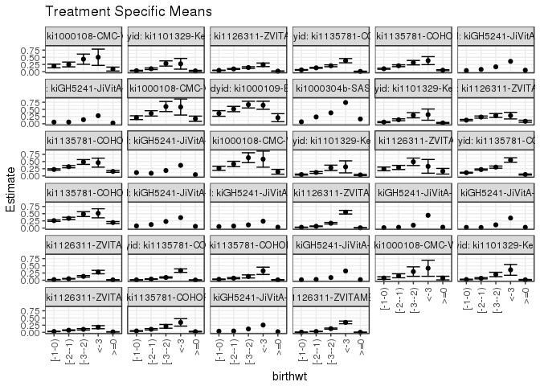

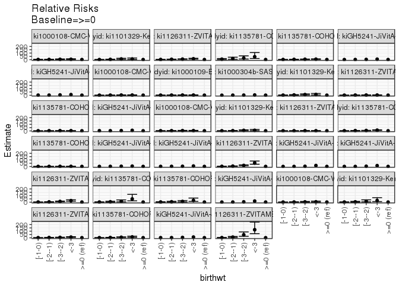

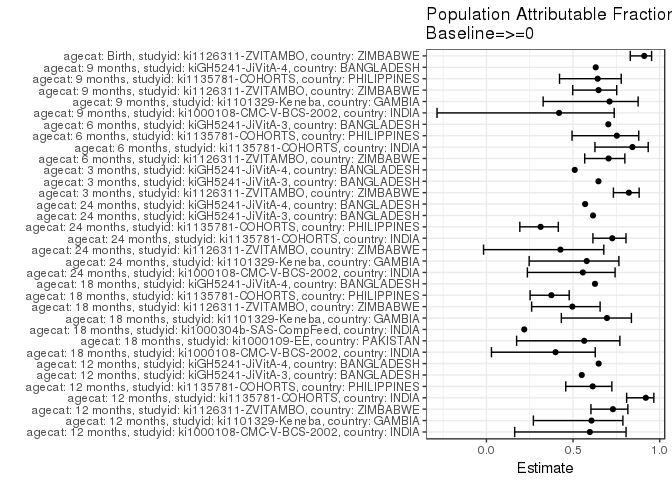

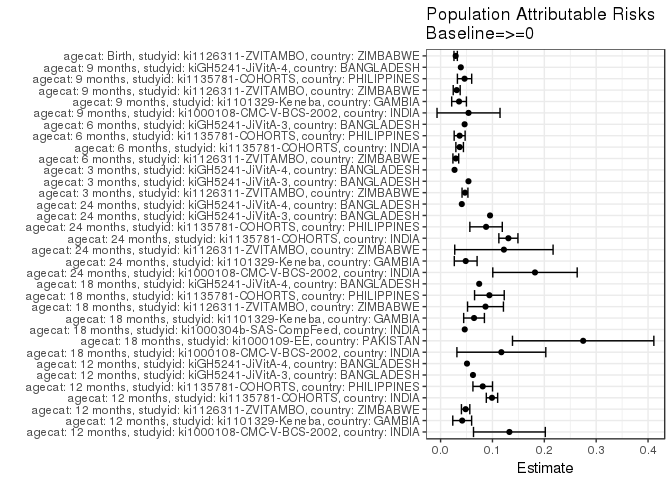

## Results Table

### Parameter: TSM

| agecat | studyid | country | intervention_level | baseline_level | estimate | ci_lower | ci_upper |
| --- | --- | --- | --- | --- | --- | --- | --- |
| Birth | ki1126311-ZVITAMBO | ZIMBABWE | >=0 | NA | 0.0028382 | 0.0009865 | 0.0046899 |
| Birth | ki1126311-ZVITAMBO | ZIMBABWE | <-3 | NA | 0.3465347 | 0.3001304 | 0.3929389 |
| Birth | ki1126311-ZVITAMBO | ZIMBABWE | [-3–2) | NA | 0.1288396 | 0.1096585 | 0.1480207 |
| Birth | ki1126311-ZVITAMBO | ZIMBABWE | [-2–1) | NA | 0.0298954 | 0.0241240 | 0.0356667 |
| Birth | ki1126311-ZVITAMBO | ZIMBABWE | [-1-0) | NA | 0.0071453 | 0.0049659 | 0.0093248 |
| 3 months | ki1126311-ZVITAMBO | ZIMBABWE | >=0 | NA | 0.0101711 | 0.0059424 | 0.0143998 |
| 3 months | ki1126311-ZVITAMBO | ZIMBABWE | <-3 | NA | 0.5514403 | 0.4889046 | 0.6139760 |
| 3 months | ki1126311-ZVITAMBO | ZIMBABWE | [-3–2) | NA | 0.1680556 | 0.1407419 | 0.1953692 |
| 3 months | ki1126311-ZVITAMBO | ZIMBABWE | [-2–1) | NA | 0.0629562 | 0.0527878 | 0.0731246 |
| 3 months | ki1126311-ZVITAMBO | ZIMBABWE | [-1-0) | NA | 0.0283485 | 0.0231023 | 0.0335947 |
| 3 months | kiGH5241-JiVitA-3 | BANGLADESH | >=0 | NA | 0.0293686 | NA | NA |
| 3 months | kiGH5241-JiVitA-3 | BANGLADESH | <-3 | NA | 0.4427295 | NA | NA |
| 3 months | kiGH5241-JiVitA-3 | BANGLADESH | [-3–2) | NA | 0.0996128 | NA | NA |
| 3 months | kiGH5241-JiVitA-3 | BANGLADESH | [-2–1) | NA | 0.0265169 | NA | NA |
| 3 months | kiGH5241-JiVitA-3 | BANGLADESH | [-1-0) | NA | 0.0142259 | NA | NA |
| 3 months | kiGH5241-JiVitA-4 | BANGLADESH | >=0 | NA | 0.0258621 | NA | NA |
| 3 months | kiGH5241-JiVitA-4 | BANGLADESH | <-3 | NA | 0.3488372 | NA | NA |
| 3 months | kiGH5241-JiVitA-4 | BANGLADESH | [-3–2) | NA | 0.1120000 | NA | NA |
| 3 months | kiGH5241-JiVitA-4 | BANGLADESH | [-2–1) | NA | 0.0207469 | NA | NA |
| 3 months | kiGH5241-JiVitA-4 | BANGLADESH | [-1-0) | NA | 0.0235849 | NA | NA |
| 6 months | ki1126311-ZVITAMBO | ZIMBABWE | >=0 | NA | 0.0122762 | 0.0073947 | 0.0171577 |
| 6 months | ki1126311-ZVITAMBO | ZIMBABWE | <-3 | NA | 0.2830189 | 0.2223776 | 0.3436601 |
| 6 months | ki1126311-ZVITAMBO | ZIMBABWE | [-3–2) | NA | 0.1334380 | 0.1070295 | 0.1598465 |
| 6 months | ki1126311-ZVITAMBO | ZIMBABWE | [-2–1) | NA | 0.0518214 | 0.0419798 | 0.0616631 |
| 6 months | ki1126311-ZVITAMBO | ZIMBABWE | [-1-0) | NA | 0.0210706 | 0.0163204 | 0.0258208 |
| 6 months | ki1135781-COHORTS | INDIA | >=0 | NA | 0.0068587 | 0.0008671 | 0.0128504 |
| 6 months | ki1135781-COHORTS | INDIA | <-3 | NA | 0.3333333 | 0.2725380 | 0.3941287 |
| 6 months | ki1135781-COHORTS | INDIA | [-3–2) | NA | 0.0950617 | 0.0748617 | 0.1152618 |
| 6 months | ki1135781-COHORTS | INDIA | [-2–1) | NA | 0.0398874 | 0.0315780 | 0.0481968 |
| 6 months | ki1135781-COHORTS | INDIA | [-1-0) | NA | 0.0122881 | 0.0078430 | 0.0167333 |

[output cut: 140 more lines]

### Parameter: E(Y)

| agecat | studyid | country | intervention_level | baseline_level | estimate | ci_lower | ci_upper |
| --- | --- | --- | --- | --- | --- | --- | --- |
| Birth | ki1126311-ZVITAMBO | ZIMBABWE | NA | NA | 0.0318872 | 0.0289588 | 0.0348156 |
| 3 months | ki1126311-ZVITAMBO | ZIMBABWE | NA | NA | 0.0571865 | 0.0524319 | 0.0619411 |
| 3 months | kiGH5241-JiVitA-3 | BANGLADESH | NA | NA | 0.0831025 | NA | NA |
| 3 months | kiGH5241-JiVitA-4 | BANGLADESH | NA | NA | 0.0527550 | NA | NA |
| 6 months | ki1126311-ZVITAMBO | ZIMBABWE | NA | NA | 0.0416213 | 0.0373152 | 0.0459273 |
| 6 months | ki1135781-COHORTS | INDIA | NA | NA | 0.0436033 | 0.0385446 | 0.0486620 |
| 6 months | ki1135781-COHORTS | PHILIPPINES | NA | NA | 0.0487988 | 0.0406160 | 0.0569816 |
| 6 months | kiGH5241-JiVitA-3 | BANGLADESH | NA | NA | 0.0658054 | NA | NA |
| 9 months | ki1000108-CMC-V-BCS-2002 | INDIA | NA | NA | 0.1284916 | 0.0937790 | 0.1632042 |
| 9 months | ki1101329-Keneba | GAMBIA | NA | NA | 0.0500874 | 0.0397670 | 0.0604077 |
| 9 months | ki1126311-ZVITAMBO | ZIMBABWE | NA | NA | 0.0479739 | 0.0431846 | 0.0527632 |
| 9 months | ki1135781-COHORTS | PHILIPPINES | NA | NA | 0.0719640 | 0.0621561 | 0.0817719 |
| 9 months | kiGH5241-JiVitA-4 | BANGLADESH | NA | NA | 0.0617978 | NA | NA |
| 12 months | ki1000108-CMC-V-BCS-2002 | INDIA | NA | NA | 0.2222222 | 0.1792169 | 0.2652276 |
| 12 months | ki1101329-Keneba | GAMBIA | NA | NA | 0.0686881 | 0.0563528 | 0.0810234 |
| 12 months | ki1126311-ZVITAMBO | ZIMBABWE | NA | NA | 0.0661120 | 0.0601756 | 0.0720485 |
| 12 months | ki1135781-COHORTS | INDIA | NA | NA | 0.1076923 | 0.0989310 | 0.1164536 |
| 12 months | ki1135781-COHORTS | PHILIPPINES | NA | NA | 0.1324686 | 0.1192928 | 0.1456443 |
| 12 months | kiGH5241-JiVitA-3 | BANGLADESH | NA | NA | 0.1134969 | NA | NA |
| 12 months | kiGH5241-JiVitA-4 | BANGLADESH | NA | NA | 0.0785781 | NA | NA |
| 18 months | ki1000108-CMC-V-BCS-2002 | INDIA | NA | NA | 0.2936288 | 0.2465839 | 0.3406737 |
| 18 months | ki1000109-EE | PAKISTAN | NA | NA | 0.4870317 | 0.4343653 | 0.5396981 |
| 18 months | ki1000304b-SAS-CompFeed | INDIA | NA | NA | 0.2131980 | NA | NA |
| 18 months | ki1101329-Keneba | GAMBIA | NA | NA | 0.0927070 | 0.0785712 | 0.1068429 |
| 18 months | ki1126311-ZVITAMBO | ZIMBABWE | NA | NA | 0.1745753 | 0.1565622 | 0.1925884 |
| 18 months | ki1135781-COHORTS | PHILIPPINES | NA | NA | 0.2509180 | 0.2337509 | 0.2680850 |
| 18 months | kiGH5241-JiVitA-4 | BANGLADESH | NA | NA | 0.1187739 | NA | NA |
| 24 months | ki1000108-CMC-V-BCS-2002 | INDIA | NA | NA | 0.3269231 | 0.2786672 | 0.3751789 |
| 24 months | ki1101329-Keneba | GAMBIA | NA | NA | 0.0836237 | 0.0692960 | 0.0979513 |
| 24 months | ki1126311-ZVITAMBO | ZIMBABWE | NA | NA | 0.2857143 | 0.2441594 | 0.3272692 |
| 24 months | ki1135781-COHORTS | INDIA | NA | NA | 0.1800041 | 0.1692028 | 0.1908054 |
| 24 months | ki1135781-COHORTS | PHILIPPINES | NA | NA | 0.2803661 | 0.2624067 | 0.2983254 |
| 24 months | kiGH5241-JiVitA-3 | BANGLADESH | NA | NA | 0.1549461 | NA | NA |
| 24 months | kiGH5241-JiVitA-4 | BANGLADESH | NA | NA | 0.0717658 | NA | NA |

### Parameter: RR

| agecat | studyid | country | intervention_level | baseline_level | estimate | ci_lower | ci_upper |
| --- | --- | --- | --- | --- | --- | --- | --- |
| Birth | ki1126311-ZVITAMBO | ZIMBABWE | >=0 | >=0 | 1.0000000 | 1.0000000 | 1.000000 |
| Birth | ki1126311-ZVITAMBO | ZIMBABWE | <-3 | >=0 | 122.0957085 | 62.7267098 | 237.655730 |
| Birth | ki1126311-ZVITAMBO | ZIMBABWE | [-3–2) | >=0 | 45.3944820 | 23.2476231 | 88.639556 |
| Birth | ki1126311-ZVITAMBO | ZIMBABWE | [-2–1) | >=0 | 10.5331339 | 5.3342372 | 20.799021 |
| Birth | ki1126311-ZVITAMBO | ZIMBABWE | [-1-0) | >=0 | 2.5175438 | 1.2251824 | 5.173129 |
| 3 months | ki1126311-ZVITAMBO | ZIMBABWE | >=0 | >=0 | 1.0000000 | 1.0000000 | 1.000000 |
| 3 months | ki1126311-ZVITAMBO | ZIMBABWE | <-3 | >=0 | 54.2166105 | 35.2350206 | 83.423844 |
| 3 months | ki1126311-ZVITAMBO | ZIMBABWE | [-3–2) | >=0 | 16.5229167 | 10.5735108 | 25.819880 |
| 3 months | ki1126311-ZVITAMBO | ZIMBABWE | [-2–1) | >=0 | 6.1897395 | 3.9624568 | 9.668970 |
| 3 months | ki1126311-ZVITAMBO | ZIMBABWE | [-1-0) | >=0 | 2.7871734 | 1.7681668 | 4.393440 |
| 3 months | kiGH5241-JiVitA-3 | BANGLADESH | >=0 | >=0 | 1.0000000 | NA | NA |
| 3 months | kiGH5241-JiVitA-3 | BANGLADESH | <-3 | >=0 | 15.0749391 | NA | NA |
| 3 months | kiGH5241-JiVitA-3 | BANGLADESH | [-3–2) | >=0 | 3.3918163 | NA | NA |
| 3 months | kiGH5241-JiVitA-3 | BANGLADESH | [-2–1) | >=0 | 0.9028989 | NA | NA |
| 3 months | kiGH5241-JiVitA-3 | BANGLADESH | [-1-0) | >=0 | 0.4843936 | NA | NA |
| 3 months | kiGH5241-JiVitA-4 | BANGLADESH | >=0 | >=0 | 1.0000000 | NA | NA |
| 3 months | kiGH5241-JiVitA-4 | BANGLADESH | <-3 | >=0 | 13.4883721 | NA | NA |
| 3 months | kiGH5241-JiVitA-4 | BANGLADESH | [-3–2) | >=0 | 4.3306667 | NA | NA |
| 3 months | kiGH5241-JiVitA-4 | BANGLADESH | [-2–1) | >=0 | 0.8022130 | NA | NA |
| 3 months | kiGH5241-JiVitA-4 | BANGLADESH | [-1-0) | >=0 | 0.9119497 | NA | NA |
| 6 months | ki1126311-ZVITAMBO | ZIMBABWE | >=0 | >=0 | 1.0000000 | 1.0000000 | 1.000000 |
| 6 months | ki1126311-ZVITAMBO | ZIMBABWE | <-3 | >=0 | 23.0542453 | 14.6751991 | 36.217445 |
| 6 months | ki1126311-ZVITAMBO | ZIMBABWE | [-3–2) | >=0 | 10.8696363 | 6.9713435 | 16.947808 |
| 6 months | ki1126311-ZVITAMBO | ZIMBABWE | [-2–1) | >=0 | 4.2212887 | 2.7168657 | 6.558763 |
| 6 months | ki1126311-ZVITAMBO | ZIMBABWE | [-1-0) | >=0 | 1.7163772 | 1.0866694 | 2.710991 |
| 6 months | ki1135781-COHORTS | INDIA | >=0 | >=0 | 1.0000000 | 1.0000000 | 1.000000 |
| 6 months | ki1135781-COHORTS | INDIA | <-3 | >=0 | 48.5999984 | 19.9096811 | 118.633736 |
| 6 months | ki1135781-COHORTS | INDIA | [-3–2) | >=0 | 13.8599995 | 5.6403893 | 34.057859 |
| 6 months | ki1135781-COHORTS | INDIA | [-2–1) | >=0 | 5.8155793 | 2.3689897 | 14.276535 |
| 6 months | ki1135781-COHORTS | INDIA | [-1-0) | >=0 | 1.7916101 | 0.6960027 | 4.611860 |

[output cut: 140 more lines]

### Parameter: PAR

| agecat | studyid | country | intervention_level | baseline_level | estimate | ci_lower | ci_upper |
| --- | --- | --- | --- | --- | --- | --- | --- |
| Birth | ki1126311-ZVITAMBO | ZIMBABWE | >=0 | NA | 0.0290490 | 0.0258192 | 0.0322788 |
| 3 months | ki1126311-ZVITAMBO | ZIMBABWE | >=0 | NA | 0.0470155 | 0.0413546 | 0.0526763 |
| 3 months | kiGH5241-JiVitA-3 | BANGLADESH | >=0 | NA | 0.0537339 | NA | NA |
| 3 months | kiGH5241-JiVitA-4 | BANGLADESH | >=0 | NA | 0.0268929 | NA | NA |
| 6 months | ki1126311-ZVITAMBO | ZIMBABWE | >=0 | NA | 0.0293451 | 0.0237685 | 0.0349216 |
| 6 months | ki1135781-COHORTS | INDIA | >=0 | NA | 0.0367445 | 0.0294555 | 0.0440336 |
| 6 months | ki1135781-COHORTS | PHILIPPINES | >=0 | NA | 0.0367298 | 0.0261677 | 0.0472920 |
| 6 months | kiGH5241-JiVitA-3 | BANGLADESH | >=0 | NA | 0.0463037 | NA | NA |
| 9 months | ki1000108-CMC-V-BCS-2002 | INDIA | >=0 | NA | 0.0538648 | -0.0068750 | 0.1146045 |
| 9 months | ki1101329-Keneba | GAMBIA | >=0 | NA | 0.0355946 | 0.0213929 | 0.0497963 |
| 9 months | ki1126311-ZVITAMBO | ZIMBABWE | >=0 | NA | 0.0310452 | 0.0243461 | 0.0377443 |
| 9 months | ki1135781-COHORTS | PHILIPPINES | >=0 | NA | 0.0461908 | 0.0324193 | 0.0599624 |
| 9 months | kiGH5241-JiVitA-4 | BANGLADESH | >=0 | NA | 0.0389841 | NA | NA |
| 12 months | ki1000108-CMC-V-BCS-2002 | INDIA | >=0 | NA | 0.1326700 | 0.0634435 | 0.2018964 |
| 12 months | ki1101329-Keneba | GAMBIA | >=0 | NA | 0.0416611 | 0.0234786 | 0.0598436 |
| 12 months | ki1126311-ZVITAMBO | ZIMBABWE | >=0 | NA | 0.0482682 | 0.0401875 | 0.0563488 |
| 12 months | ki1135781-COHORTS | INDIA | >=0 | NA | 0.0990716 | 0.0881298 | 0.1100134 |
| 12 months | ki1135781-COHORTS | PHILIPPINES | >=0 | NA | 0.0812318 | 0.0623429 | 0.1001207 |
| 12 months | kiGH5241-JiVitA-3 | BANGLADESH | >=0 | NA | 0.0624498 | NA | NA |
| 12 months | kiGH5241-JiVitA-4 | BANGLADESH | >=0 | NA | 0.0509101 | NA | NA |
| 18 months | ki1000108-CMC-V-BCS-2002 | INDIA | >=0 | NA | 0.1171582 | 0.0314586 | 0.2028578 |
| 18 months | ki1000109-EE | PAKISTAN | >=0 | NA | 0.2749105 | 0.1386251 | 0.4111959 |
| 18 months | ki1000304b-SAS-CompFeed | INDIA | >=0 | NA | 0.0465313 | NA | NA |
| 18 months | ki1101329-Keneba | GAMBIA | >=0 | NA | 0.0644939 | 0.0444958 | 0.0844919 |
| 18 months | ki1126311-ZVITAMBO | ZIMBABWE | >=0 | NA | 0.0865753 | 0.0519781 | 0.1211724 |
| 18 months | ki1135781-COHORTS | PHILIPPINES | >=0 | NA | 0.0940914 | 0.0654972 | 0.1226856 |
| 18 months | kiGH5241-JiVitA-4 | BANGLADESH | >=0 | NA | 0.0744191 | NA | NA |
| 24 months | ki1000108-CMC-V-BCS-2002 | INDIA | >=0 | NA | 0.1819955 | 0.1006075 | 0.2633836 |
| 24 months | ki1101329-Keneba | GAMBIA | >=0 | NA | 0.0484124 | 0.0264329 | 0.0703920 |
| 24 months | ki1126311-ZVITAMBO | ZIMBABWE | >=0 | NA | 0.1220779 | 0.0272584 | 0.2168974 |
| 24 months | ki1135781-COHORTS | INDIA | >=0 | NA | 0.1307430 | 0.1123551 | 0.1491309 |
| 24 months | ki1135781-COHORTS | PHILIPPINES | >=0 | NA | 0.0876878 | 0.0564303 | 0.1189453 |
| 24 months | kiGH5241-JiVitA-3 | BANGLADESH | >=0 | NA | 0.0953434 | NA | NA |
| 24 months | kiGH5241-JiVitA-4 | BANGLADESH | >=0 | NA | 0.0408778 | NA | NA |

### Parameter: PAF

| agecat | studyid | country | intervention_level | baseline_level | estimate | ci_lower | ci_upper |
| --- | --- | --- | --- | --- | --- | --- | --- |
| Birth | ki1126311-ZVITAMBO | ZIMBABWE | >=0 | NA | 0.9109918 | 0.8302617 | 0.9533255 |
| 3 months | ki1126311-ZVITAMBO | ZIMBABWE | >=0 | NA | 0.8221423 | 0.7329339 | 0.8815524 |
| 3 months | kiGH5241-JiVitA-3 | BANGLADESH | >=0 | NA | 0.6465981 | NA | NA |
| 3 months | kiGH5241-JiVitA-4 | BANGLADESH | >=0 | NA | 0.5097701 | NA | NA |
| 6 months | ki1126311-ZVITAMBO | ZIMBABWE | >=0 | NA | 0.7050497 | 0.5673650 | 0.7989166 |
| 6 months | ki1135781-COHORTS | INDIA | >=0 | NA | 0.8427019 | 0.6263242 | 0.9337856 |
| 6 months | ki1135781-COHORTS | PHILIPPINES | >=0 | NA | 0.7526790 | 0.4941309 | 0.8790840 |
| 6 months | kiGH5241-JiVitA-3 | BANGLADESH | >=0 | NA | 0.7036469 | NA | NA |
| 9 months | ki1000108-CMC-V-BCS-2002 | INDIA | >=0 | NA | 0.4192083 | -0.2852535 | 0.7375467 |
| 9 months | ki1101329-Keneba | GAMBIA | >=0 | NA | 0.7106504 | 0.3272235 | 0.8755557 |
| 9 months | ki1126311-ZVITAMBO | ZIMBABWE | >=0 | NA | 0.6471274 | 0.4979841 | 0.7519619 |
| 9 months | ki1135781-COHORTS | PHILIPPINES | >=0 | NA | 0.6418600 | 0.4219632 | 0.7781036 |
| 9 months | kiGH5241-JiVitA-4 | BANGLADESH | >=0 | NA | 0.6308330 | NA | NA |
| 12 months | ki1000108-CMC-V-BCS-2002 | INDIA | >=0 | NA | 0.5970149 | 0.1629698 | 0.8059843 |
| 12 months | ki1101329-Keneba | GAMBIA | >=0 | NA | 0.6065254 | 0.2709126 | 0.7876493 |
| 12 months | ki1126311-ZVITAMBO | ZIMBABWE | >=0 | NA | 0.7300965 | 0.6032910 | 0.8163694 |
| 12 months | ki1135781-COHORTS | INDIA | >=0 | NA | 0.9199507 | 0.8092768 | 0.9664022 |
| 12 months | ki1135781-COHORTS | PHILIPPINES | >=0 | NA | 0.6132158 | 0.4578852 | 0.7240399 |
| 12 months | kiGH5241-JiVitA-3 | BANGLADESH | >=0 | NA | 0.5502335 | NA | NA |
| 12 months | kiGH5241-JiVitA-4 | BANGLADESH | >=0 | NA | 0.6478920 | NA | NA |
| 18 months | ki1000108-CMC-V-BCS-2002 | INDIA | >=0 | NA | 0.3990011 | 0.0289673 | 0.6280252 |
| 18 months | ki1000109-EE | PAKISTAN | >=0 | NA | 0.5644612 | 0.1741419 | 0.7703067 |
| 18 months | ki1000304b-SAS-CompFeed | INDIA | >=0 | NA | 0.2182540 | NA | NA |
| 18 months | ki1101329-Keneba | GAMBIA | >=0 | NA | 0.6956740 | 0.4324167 | 0.8368269 |
| 18 months | ki1126311-ZVITAMBO | ZIMBABWE | >=0 | NA | 0.4959194 | 0.2608978 | 0.6562082 |
| 18 months | ki1135781-COHORTS | PHILIPPINES | >=0 | NA | 0.3749887 | 0.2520069 | 0.4777504 |
| 18 months | kiGH5241-JiVitA-4 | BANGLADESH | >=0 | NA | 0.6265609 | NA | NA |
| 24 months | ki1000108-CMC-V-BCS-2002 | INDIA | >=0 | NA | 0.5566922 | 0.2363221 | 0.7426641 |
| 24 months | ki1101329-Keneba | GAMBIA | >=0 | NA | 0.5789319 | 0.2466470 | 0.7646544 |
| 24 months | ki1126311-ZVITAMBO | ZIMBABWE | >=0 | NA | 0.4272727 | -0.0167144 | 0.6773759 |
| 24 months | ki1135781-COHORTS | INDIA | >=0 | NA | 0.7263336 | 0.6147135 | 0.8056166 |
| 24 months | ki1135781-COHORTS | PHILIPPINES | >=0 | NA | 0.3127619 | 0.1927077 | 0.4149626 |
| 24 months | kiGH5241-JiVitA-3 | BANGLADESH | >=0 | NA | 0.6153330 | NA | NA |
| 24 months | kiGH5241-JiVitA-4 | BANGLADESH | >=0 | NA | 0.5695997 | NA | NA |